# **TOPIC MODELLING ON NEWS WEBLINKS USING LDA**

https://colab.research.google.com/drive/1EJfAZ9zoia4U0wv8C5eOcCXAkx0w_5Lc?usp=sharing

*by GROUP 2 (**Joey Tuason**, Alex Gamboa)*

# **I. INTRODUCTION**

Given a list of news weblinks, our group shall be using the unsupervised modelling for Topic Modelling by using the Latent Dirichlet Allocation (LDA) model to determine what are the topics generated by simply having the web address. We will attempt to make sense of such grouping.

# **II. DATASET**

Dataset is comprised of two files. The below name and schema are lifted from the website and will shall be elaborated after.

**FIRST DATASET: newsCorpora.csv**

**ID** Numeric ID  
**TITLE** News title  
**URL** Url  
**PUBLISHER** Publisher name  
**CATEGORY** News category (b = business, t = science and technology, e = entertainment, m = health)  
**STORY** Alphanumeric ID of the cluster that includes news about the same story  
**HOSTNAME** Url hostname  
**TIMESTAMP** Approximate time the news was published, as the number of milliseconds since the epoch 00:00:00 GMT, January 1, 1970

**SECOND DATASET: 2pageSessions.csv**

For the first dataset, we will look into the TITLE. But as we shall see below, some of the titles will not be useful so we will do data cleaning to sort these out and replace them with their corresponding URL.

For the second dataset, we will solely be relying on the URL. As we shall see below, the main issue for the second dataset are the duplicates.

After which, we shall consolidate both and perform LDA.

# **III. PROBLEM STATEMENT**

**Primary**: Beyond the current categories provided, can we create a new and descriptive groupings of the articles to determine what types of news are being released on the internet?

**Secondary**: Is there a possibility that certain hostname/urls are leaning towards a certain topic?

The secondary problem statement was not attempted in this run. Suggest to have look into this after.

# **IV. METHODS**

This project would be using the LDA (Latent Dirichlet Allocation) model to group these websites into the topic resulted from the mining.

# **V. LOADING THE DATA**

We have two sets of data:

1. First dataset of URLs over 400k+ with the news article title carved out properly. Only issue is that some of the entries in the TITLE column is "Posted by". This means we only have the author but not what the article is about. This data needs to be trasformed.
2. Second dataset of URLs over 10k+ without the news article title. Since we need to do NLP, transformation is needed.

Also both datasets have duplicates so we need to remove them.

## **A. PACKAGES**

```python
# Data manipulation package used
import pandas as pd

# Data visualization packages used
import matplotlib.pyplot as plt
%matplotlib inline

## Word Cloud
!pip install wordcloud
from wordcloud import WordCloud
from wordcloud import ImageColorGenerator
from wordcloud import STOPWORDS
import matplotlib.pyplot as plt

## Word Histogram
import seaborn as sns
from nltk import FreqDist

# LDA Packages used

## Processing the data for LDA
import nltk
#nltk.download('stopwords')
from nltk.corpus import stopwords

!pip install spacy
import spacy

import gensim
from gensim import corpora

## Dashboard for LDA
!pip install pyLDAvis
import pyLDAvis
import pyLDAvis.gensim_models

# Ignore unnecessariy warnings
import warnings
warnings.filterwarnings("ignore")
```

## **B. LOAD DATASET**

Load dataset from google drive to colab.

Load dataset in colab and define the columns.

```python
df1_colnames = ['ID','TITLE','URL','PUBLISHER','CATEGORY','STORY','HOSTNAME','TIMESTAMP']
df2_colnames = ['STORY','HOSTNAME','CATEGORY','URL']

df1 = pd.read_csv('newsCorpora.csv', delimiter='\t', header=None, names=df1_colnames)
df2 = pd.read_csv('2pageSessions.csv', delimiter='\t', header=None, names=df2_colnames)
```

# **VI. DATA CLEANING/PRE-PROCESSING**

## **A. DATA CHECKING**

Look into the data to determine whether cleaning and transformations are needed to be done. After which, we will consolidate them into one dataset.

```python
df1.columns
```

```
Index(['ID', 'TITLE', 'URL', 'PUBLISHER', 'CATEGORY', 'STORY', 'HOSTNAME',
       'TIMESTAMP'],
      dtype='object')
```

```python
df2.columns
```

```
Index(['STORY', 'HOSTNAME', 'CATEGORY', 'URL'], dtype='object')
```

```python
df1.head()
```

|  | ID | TITLE | URL | PUBLISHER | CATEGORY | STORY | HOSTNAME | TIMESTAMP |
| --- | --- | --- | --- | --- | --- | --- | --- | --- |
| 0 | 1 | Fed official says weak data caused by weather,... | http://www.latimes.com/business/money/la-fi-mo... | Los Angeles Times | b | ddUyU0VZz0BRneMioxUPQVP6sIxvM | www.latimes.com | 1394470370698 |
| 1 | 2 | Fed's Charles Plosser sees high bar for change... | http://www.livemint.com/Politics/H2EvwJSK2VE6O... | Livemint | b | ddUyU0VZz0BRneMioxUPQVP6sIxvM | www.livemint.com | 1394470371207 |
| 2 | 3 | US open: Stocks fall after Fed official hints ... | http://www.ifamagazine.com/news/us-open-stocks... | IFA Magazine | b | ddUyU0VZz0BRneMioxUPQVP6sIxvM | www.ifamagazine.com | 1394470371550 |
| 3 | 4 | Fed risks falling 'behind the curve', Charles ... | http://www.ifamagazine.com/news/fed-risks-fall... | IFA Magazine | b | ddUyU0VZz0BRneMioxUPQVP6sIxvM | www.ifamagazine.com | 1394470371793 |
| 4 | 5 | Fed's Plosser: Nasty Weather Has Curbed Job Gr... | http://www.moneynews.com/Economy/federal-reser... | Moneynews | b | ddUyU0VZz0BRneMioxUPQVP6sIxvM | www.moneynews.com | 1394470372027 |

For the second dataset, we would be needing the data under the URL column. The following cleaning and transformation are needed to be done:

1. Separate the two URLS. We would need the second URL.
2. There are duplicate URLS. These have to be removed and reported as only one entity.

```python
df2.head()
```

|  | STORY | HOSTNAME | CATEGORY | URL |
| --- | --- | --- | --- | --- |
| 0 | dxyGGb4iN9Cs9aMZTKQpJeoiQfruM | techcrunch.com | b | http://techcrunch.com/ http://techcrunch.com/2... |
| 1 | dxyGGb4iN9Cs9aMZTKQpJeoiQfruM | techcrunch.com | b | http://techcrunch.com/ecommerce/ http://techcr... |
| 2 | dxyGGb4iN9Cs9aMZTKQpJeoiQfruM | www.bnn.ca | b | http://www.bnn.ca/News/2014/ http://www.bnn.ca... |
| 3 | dxyGGb4iN9Cs9aMZTKQpJeoiQfruM | www.bnn.ca | b | http://www.bnn.ca/news http://www.bnn.ca/News/... |
| 4 | dxyGGb4iN9Cs9aMZTKQpJeoiQfruM | www.bnn.ca | b | http://www.bnn.ca/News/News-Listing.aspx?Secto... |

```python
print(df1.shape)
print(df2.shape)
```

```
(422419, 8)
(15516, 4)
```

```python
df1.describe()
```

|  | ID | TIMESTAMP |
| --- | --- | --- |
| count | 422419.000000 | 4.224190e+05 |
| mean | 211536.764594 | 1.400445e+12 |
| std | 122102.839707 | 3.733088e+09 |
| min | 1.000000 | 1.394470e+12 |
| 25% | 105801.500000 | 1.397349e+12 |
| 50% | 211655.000000 | 1.399990e+12 |
| 75% | 317273.500000 | 1.403775e+12 |
| max | 422937.000000 | 1.409229e+12 |

```python
df1.value_counts()
```

```
ID      TITLE                                                                           URL                                                                                                                          PUBLISHER                     CATEGORY  STORY                          HOSTNAME        …
1       Fed official says weak data caused by weather, should not slow taper            http://www.latimes.com/business/money/la-fi-mo-federal-reserve-plosser-stimulus-economy-20140310,0,1312750.story\?track=rss  Los Angeles Times             b         ddUyU0VZz0BRneMioxUPQVP6sIxvM  www.latimes.com …
282070  US MIDDAY: wheat falls                                                          http://www.brecorder.com/agriculture-a-allied/183/1191630/                                                                   Business Recorder             b         dcXK5M-xGG8o_TMLBukCi4fumIc7M  www.brecorder.co…
282080  Crop futures stabilized in the wake of Wednesday's losses                       http://www.agprofessional.com/news/Crop-futures-stabilized-in-the-wake-of-Wednesdays-losses-262854391.html                   agprofessional.com            b         dcXK5M-xGG8o_TMLBukCi4fumIc7M  www.agprofession…
282079  Healthy soy stocks/use ratio in 2015                                            http://www.blackseagrain.net/novosti/healthy-soy-stocks-use-ratio-in-2015                                                    UkrAgroConsult                b         dcXK5M-xGG8o_TMLBukCi4fumIc7M  www.blackseagrai…
282078  WASDE: Record Corn Crop Remains Predicted                                       http://seekingalpha.com/article/2265493-wasde-record-corn-crop-remains-predicted\?source=google_news                         Seeking Alpha                 b         dcXK5M-xGG8o_TMLBukCi4fumIc7M  seekingalpha.com…
                                                                                                                                                                                                                                                                                                            …
141141  Decatur County battles cancer through Relay for Life                            http://topnews.ae/content/220640-decatur-county-battles-cancer-through-relay-life                                            TopNews Arab Emirates         m         d6OGaCFKvfMxcCMwR26Fn5F-Cz94M  topnews.ae      …
141140  Calloway's Relay For Life Kicks Off Tonight                                     http://wkms.org/post/calloways-relay-life-kicks-tonight                                                                      WKMS                          m         d6OGaCFKvfMxcCMwR26Fn5F-Cz94M  wkms.org        …
141139  UofL students, staff participate in Relay for Life on Good Friday               http://www.whas11.com/news/UofL-students-staff-participate-in-Relay-for-Life-on-Good-Friday-255829311.html                   WHAS 11.com \(subscription\)  m         d6OGaCFKvfMxcCMwR26Fn5F-Cz94M  www.whas11.com  …
141138  Relay for Life set for May 2                                                    http://thedailysentinel.com/news/article_4e6c9286-c743-11e3-9e34-001a4bcf887a.html                                           Scottsboro Daily Sentinel     m         d6OGaCFKvfMxcCMwR26Fn5F-Cz94M  thedailysentinel…
422937  Phoenix boy undergoes surgery to repair throat damage - CBS 3 Springfield  ...  http://www.cbs3springfield.com/story/26368078/phoenix-boy-undergoes-surgery-to-repair-throat-damage-from-button-battery      WSHM-TV                       m         dpcLMoJD69UYMXMxaoEFnWql9YjQM  www.cbs3springfi…
Length: 422417, dtype: int64
```

```python
df2.describe()
```

|  | STORY | HOSTNAME | CATEGORY | URL |
| --- | --- | --- | --- | --- |
| count | 15516 | 15516 | 15516 | 15516 |
| unique | 943 | 434 | 2 | 15506 |
| top | d--MozT4MsoFfIMgKu5_N58OF_f9M | www.investing.com | e | http://www.benzinga.com/topic/chapter-11 http:... |
| freq | 666 | 750 | 9425 | 2 |

```python
df2.value_counts()
```

```
STORY                          HOSTNAME                   CATEGORY  URL
dhpby_46Ae5iB8ME-y0QZ8gSCJwLM  www.brecorder.com          b         http://www.brecorder.com/markets/fxmm/ http://www.brecorder.com/markets/fxmm/americas/167030-dollar-stumbles-as-rate-hike-expectations-pushed-back.html                                                   2
dJVPX-uN99u_nuMNg-WrOZuHDxacM  www.hollywoodreporter.com  b         http://www.hollywoodreporter.com/heat-vision/ http://www.hollywoodreporter.com/heat-vision/comics-industry-reacts-amazon-acquisition-695438                                                               2
dhpby_46Ae5iB8ME-y0QZ8gSCJwLM  www.brecorder.com          b         http://www.brecorder.com/markets/fxmm/ http://www.brecorder.com/markets/fxmm/americas/167254-dollar-steadies-ahead-of-yellen-appearances-next-week.html                                                   2
                                                                    http://www.brecorder.com/markets/fxmm/americas/ http://www.brecorder.com/markets/fxmm/americas/167195-dollar-edges-higher-on-equities-gloom.html                                                          2
                                                                    http://www.brecorder.com/markets/fxmm/europe/ http://www.brecorder.com/markets/fxmm/europe/167148-no-respite-for-dollar-after-rough-week.html                                                             2
                                                                                                                                                                                                                                                                             ..
dHmpog6unxaYYaMzYMEdbkeDeB9iM  www.kmbc.com               e         http://www.kmbc.com/weather/radar http://www.kmbc.com/news/juan-pablo-makes-his-decision-in-the-bachelor-finale/24908758                                                                                  1
                               www.nj.com                 e         http://connect.nj.com/staff/amyrowe91/posts.html http://www.nj.com/entertainment/tv/index.ssf/2014/03/the_bachelor_finale_recap_juan_pablo_chooses_nikki.html                                             1
                               www.orlandosentinel.com    e         http://www.orlandosentinel.com/entertainment/ http://www.orlandosentinel.com/entertainment/blogs/tv-guy/os-bachelor-ends-believe-debuts-big-bang-theory-reunion-20140309,0,7387981.post                   1
                                                                    http://www.orlandosentinel.com/entertainment/blogs/tv-guy/ http://www.orlandosentinel.com/entertainment/blogs/tv-guy/os-bachelor-ends-believe-debuts-big-bang-theory-reunion-20140309,0,7387981.post      1
dzykv2fHQ_Evt6MrDtf5L0FbPMiqM  wallstcheatsheet.com       b         http://wallstcheatsheet.com/politics/confidence-becoming-harder-to-find-in-this-economy.html/ http://wallstcheatsheet.com/politics/confidence-becoming-harder-to-find-in-this-economy.html/?a=viewall     1
Length: 15506, dtype: int64
```

```python
df1.nunique() == 0
```

```
ID           False
TITLE        False
URL          False
PUBLISHER    False
CATEGORY     False
STORY        False
HOSTNAME     False
TIMESTAMP    False
dtype: bool
```

```python
df2.nunique() == 0
```

```
STORY       False
HOSTNAME    False
CATEGORY    False
URL         False
dtype: bool
```

```python
df1.tail()
```

|  | ID | TITLE | URL | PUBLISHER | CATEGORY | STORY | HOSTNAME | TIMESTAMP |
| --- | --- | --- | --- | --- | --- | --- | --- | --- |
| 422414 | 422933 | Surgeons to remove 4-year-old's rib to rebuild... | http://www.cbs3springfield.com/story/26378648/... | WSHM-TV | m | dpcLMoJD69UYMXMxaoEFnWql9YjQM | www.cbs3springfield.com | 1409229190251 |
| 422415 | 422934 | Boy to have surgery on esophagus after battery... | http://www.wlwt.com/news/boy-to-have-surgery-o... | WLWT Cincinnati | m | dpcLMoJD69UYMXMxaoEFnWql9YjQM | www.wlwt.com | 1409229190508 |
| 422416 | 422935 | Child who swallowed battery to have reconstruc... | http://www.newsnet5.com/news/local-news/child-... | NewsNet5.com | m | dpcLMoJD69UYMXMxaoEFnWql9YjQM | www.newsnet5.com | 1409229190771 |
| 422417 | 422936 | Phoenix boy undergoes surgery to repair throat... | http://www.wfsb.com/story/26368078/phoenix-boy... | WFSB | m | dpcLMoJD69UYMXMxaoEFnWql9YjQM | www.wfsb.com | 1409229191071 |
| 422418 | 422937 | Phoenix boy undergoes surgery to repair throat... | http://www.cbs3springfield.com/story/26368078/... | WSHM-TV | m | dpcLMoJD69UYMXMxaoEFnWql9YjQM | www.cbs3springfield.com | 1409229191565 |

```python
df2.tail()
```

|  | STORY | HOSTNAME | CATEGORY | URL |
| --- | --- | --- | --- | --- |
| 15511 | dkPjabOt_3c58pM7cXTzwf0VDxtQM | www.upi.com | b | http://www.upi.com/ http://www.upi.com/Busines... |
| 15512 | dkPjabOt_3c58pM7cXTzwf0VDxtQM | www.webpronews.com | b | http://www.webpronews.com/ http://www.webprone... |
| 15513 | d3DTRVmvpPPpa8MG61j9MfjG4GkuM | www.smh.com.au | b | http://www.theage.com.au/travel/traveller-tips... |
| 15514 | d3DTRVmvpPPpa8MG61j9MfjG4GkuM | www.smh.com.au | b | http://www.theage.com.au/travel http://www.smh... |
| 15515 | dPp5hgOXcGU6jDMtiVyefPqR7BwhM | www.smh.com.au | e | http://www.theage.com.au/lifestyle http://www.... |

We note that the PUBLISHER column in the first dataset has 2 null values. It would not matter in our NLP run so we leave it as is.

```python
df1.info()
```

```
<class 'pandas.core.frame.DataFrame'>
RangeIndex: 422419 entries, 0 to 422418
Data columns (total 8 columns):
 #   Column     Non-Null Count   Dtype
---  ------     --------------   -----
 0   ID         422419 non-null  int64
 1   TITLE      422419 non-null  object
 2   URL        422419 non-null  object
 3   PUBLISHER  422417 non-null  object
 4   CATEGORY   422419 non-null  object
 5   STORY      422419 non-null  object
 6   HOSTNAME   422419 non-null  object
 7   TIMESTAMP  422419 non-null  int64
dtypes: int64(2), object(6)
memory usage: 25.8+ MB
```

```python
df2.info()
```

```
<class 'pandas.core.frame.DataFrame'>
RangeIndex: 15516 entries, 0 to 15515
Data columns (total 4 columns):
 #   Column    Non-Null Count  Dtype
---  ------    --------------  -----
 0   STORY     15516 non-null  object
 1   HOSTNAME  15516 non-null  object
 2   CATEGORY  15516 non-null  object
 3   URL       15516 non-null  object
dtypes: object(4)
memory usage: 485.0+ KB
```

```python
df1.notnull().sum()
```

```
ID           422419
TITLE        422419
URL          422419
PUBLISHER    422417
CATEGORY     422419
STORY        422419
HOSTNAME     422419
TIMESTAMP    422419
dtype: int64
```

```python
df2.notnull().sum()
```

```
STORY       15516
HOSTNAME    15516
CATEGORY    15516
URL         15516
dtype: int64
```

```python
df1.dtypes
```

```
ID            int64
TITLE        object
URL          object
PUBLISHER    object
CATEGORY     object
STORY        object
HOSTNAME     object
TIMESTAMP     int64
dtype: object
```

```python
df2.dtypes
```

```
STORY       object
HOSTNAME    object
CATEGORY    object
URL         object
dtype: object
```

```python
print(df1.nunique())
print(df2.nunique())
```

```
ID           422419
TITLE        406455
URL          422223
PUBLISHER     10985
CATEGORY          4
STORY          7230
HOSTNAME      11236
TIMESTAMP    422419
dtype: int64
STORY         943
HOSTNAME      434
CATEGORY        2
URL         15506
dtype: int64
```

```python
df1
```

|  | ID | TITLE | URL | PUBLISHER | CATEGORY | STORY | HOSTNAME | TIMESTAMP |
| --- | --- | --- | --- | --- | --- | --- | --- | --- |
| 0 | 1 | Fed official says weak data caused by weather,... | http://www.latimes.com/business/money/la-fi-mo... | Los Angeles Times | b | ddUyU0VZz0BRneMioxUPQVP6sIxvM | www.latimes.com | 1394470370698 |
| 1 | 2 | Fed's Charles Plosser sees high bar for change... | http://www.livemint.com/Politics/H2EvwJSK2VE6O... | Livemint | b | ddUyU0VZz0BRneMioxUPQVP6sIxvM | www.livemint.com | 1394470371207 |
| 2 | 3 | US open: Stocks fall after Fed official hints ... | http://www.ifamagazine.com/news/us-open-stocks... | IFA Magazine | b | ddUyU0VZz0BRneMioxUPQVP6sIxvM | www.ifamagazine.com | 1394470371550 |
| 3 | 4 | Fed risks falling 'behind the curve', Charles ... | http://www.ifamagazine.com/news/fed-risks-fall... | IFA Magazine | b | ddUyU0VZz0BRneMioxUPQVP6sIxvM | www.ifamagazine.com | 1394470371793 |
| 4 | 5 | Fed's Plosser: Nasty Weather Has Curbed Job Gr... | http://www.moneynews.com/Economy/federal-reser... | Moneynews | b | ddUyU0VZz0BRneMioxUPQVP6sIxvM | www.moneynews.com | 1394470372027 |
| ... | ... | ... | ... | ... | ... | ... | ... | ... |
| 422414 | 422933 | Surgeons to remove 4-year-old's rib to rebuild... | http://www.cbs3springfield.com/story/26378648/... | WSHM-TV | m | dpcLMoJD69UYMXMxaoEFnWql9YjQM | www.cbs3springfield.com | 1409229190251 |
| 422415 | 422934 | Boy to have surgery on esophagus after battery... | http://www.wlwt.com/news/boy-to-have-surgery-o... | WLWT Cincinnati | m | dpcLMoJD69UYMXMxaoEFnWql9YjQM | www.wlwt.com | 1409229190508 |
| 422416 | 422935 | Child who swallowed battery to have reconstruc... | http://www.newsnet5.com/news/local-news/child-... | NewsNet5.com | m | dpcLMoJD69UYMXMxaoEFnWql9YjQM | www.newsnet5.com | 1409229190771 |
| 422417 | 422936 | Phoenix boy undergoes surgery to repair throat... | http://www.wfsb.com/story/26368078/phoenix-boy... | WFSB | m | dpcLMoJD69UYMXMxaoEFnWql9YjQM | www.wfsb.com | 1409229191071 |
| 422418 | 422937 | Phoenix boy undergoes surgery to repair throat... | http://www.cbs3springfield.com/story/26368078/... | WSHM-TV | m | dpcLMoJD69UYMXMxaoEFnWql9YjQM | www.cbs3springfield.com | 1409229191565 |

422419 rows × 8 columns

```python
df2
```

|  | STORY | HOSTNAME | CATEGORY | URL |
| --- | --- | --- | --- | --- |
| 0 | dxyGGb4iN9Cs9aMZTKQpJeoiQfruM | techcrunch.com | b | http://techcrunch.com/ http://techcrunch.com/2... |
| 1 | dxyGGb4iN9Cs9aMZTKQpJeoiQfruM | techcrunch.com | b | http://techcrunch.com/ecommerce/ http://techcr... |
| 2 | dxyGGb4iN9Cs9aMZTKQpJeoiQfruM | www.bnn.ca | b | http://www.bnn.ca/News/2014/ http://www.bnn.ca... |
| 3 | dxyGGb4iN9Cs9aMZTKQpJeoiQfruM | www.bnn.ca | b | http://www.bnn.ca/news http://www.bnn.ca/News/... |
| 4 | dxyGGb4iN9Cs9aMZTKQpJeoiQfruM | www.bnn.ca | b | http://www.bnn.ca/News/News-Listing.aspx?Secto... |
| ... | ... | ... | ... | ... |
| 15511 | dkPjabOt_3c58pM7cXTzwf0VDxtQM | www.upi.com | b | http://www.upi.com/ http://www.upi.com/Busines... |
| 15512 | dkPjabOt_3c58pM7cXTzwf0VDxtQM | www.webpronews.com | b | http://www.webpronews.com/ http://www.webprone... |
| 15513 | d3DTRVmvpPPpa8MG61j9MfjG4GkuM | www.smh.com.au | b | http://www.theage.com.au/travel/traveller-tips... |
| 15514 | d3DTRVmvpPPpa8MG61j9MfjG4GkuM | www.smh.com.au | b | http://www.theage.com.au/travel http://www.smh... |
| 15515 | dPp5hgOXcGU6jDMtiVyefPqR7BwhM | www.smh.com.au | e | http://www.theage.com.au/lifestyle http://www.... |

15516 rows × 4 columns

Let us look at the last character of the URL column. This will help us later on how to extract the last portion of the URL.

Given the results, we see that the "/" is not necessarily the last character. Note this for later when we are splitting this column.

```python
df2['URL'].str.strip().str[-1].unique()
```

```
array(['/', 'x', 'o', '0', '4', '8', 'l', 'y', 't', '1', 'm', 'p', 's',
       'e', '9', '5', '2', 'n', 'r', 'g', 'w', 'a', 'd', 'C', '6', 'h',
       '3', 'i', 'O', '7', 'L', 'f', 'c', 'k', '_', 'b', 'E', '-', 'W',
       '=', 'u', 'V'], dtype=object)
```

## **B. DATA CLEANING**

We shall look clean the first dataset then move to the second.

### **--FIRST DATASET**

Remove duplicate title lines and hostname.

```python
df1_step1 = df1.drop_duplicates(subset = ['TITLE','HOSTNAME'], keep = 'first', ignore_index=True)
df1_step1.info()
df1_step1.head()
```

```
<class 'pandas.core.frame.DataFrame'>
RangeIndex: 417037 entries, 0 to 417036
Data columns (total 8 columns):
 #   Column     Non-Null Count   Dtype
---  ------     --------------   -----
 0   ID         417037 non-null  int64
 1   TITLE      417037 non-null  object
 2   URL        417037 non-null  object
 3   PUBLISHER  417035 non-null  object
 4   CATEGORY   417037 non-null  object
 5   STORY      417037 non-null  object
 6   HOSTNAME   417037 non-null  object
 7   TIMESTAMP  417037 non-null  int64
dtypes: int64(2), object(6)
memory usage: 25.5+ MB
```

|  | ID | TITLE | URL | PUBLISHER | CATEGORY | STORY | HOSTNAME | TIMESTAMP |
| --- | --- | --- | --- | --- | --- | --- | --- | --- |
| 0 | 1 | Fed official says weak data caused by weather,... | http://www.latimes.com/business/money/la-fi-mo... | Los Angeles Times | b | ddUyU0VZz0BRneMioxUPQVP6sIxvM | www.latimes.com | 1394470370698 |
| 1 | 2 | Fed's Charles Plosser sees high bar for change... | http://www.livemint.com/Politics/H2EvwJSK2VE6O... | Livemint | b | ddUyU0VZz0BRneMioxUPQVP6sIxvM | www.livemint.com | 1394470371207 |
| 2 | 3 | US open: Stocks fall after Fed official hints ... | http://www.ifamagazine.com/news/us-open-stocks... | IFA Magazine | b | ddUyU0VZz0BRneMioxUPQVP6sIxvM | www.ifamagazine.com | 1394470371550 |
| 3 | 4 | Fed risks falling 'behind the curve', Charles ... | http://www.ifamagazine.com/news/fed-risks-fall... | IFA Magazine | b | ddUyU0VZz0BRneMioxUPQVP6sIxvM | www.ifamagazine.com | 1394470371793 |
| 4 | 5 | Fed's Plosser: Nasty Weather Has Curbed Job Gr... | http://www.moneynews.com/Economy/federal-reser... | Moneynews | b | ddUyU0VZz0BRneMioxUPQVP6sIxvM | www.moneynews.com | 1394470372027 |

Now we look at the titles which contains "Posted by". We need to replace these with the URL equivalent.

```python
df1_step1[df1_step1['TITLE'].str.contains("Posted by")].head()
```

|  | ID | TITLE | URL | PUBLISHER | CATEGORY | STORY | HOSTNAME | TIMESTAMP |
| --- | --- | --- | --- | --- | --- | --- | --- | --- |
| 307 | 308 | Posted by Parvez Jabri | http://www.brecorder.com/world/southeast-asia/... | Business Recorder | b | d85PwV5UxEUaHMM0to00pLgkAXkbM | www.brecorder.com | 1394474341900 |
| 843 | 845 | Posted by Shoaib-ur-Rehman Siddiqui | http://www.brecorder.com/markets/commodities/a... | Business Recorder | b | dn8H6sYjpAZnsgM2qvfMRDttKqhXM | www.brecorder.com | 1394490297688 |
| 13170 | 13208 | Posted by Muhammad Iqbal | http://www.brecorder.com/world/global-business... | Business Recorder | b | d-fS70CRDM7tVXMmqQCeLIbVI1-yM | www.brecorder.com | 1395058713119 |
| 35512 | 35671 | Posted by Abdul Ahad | http://www.brecorder.com/markets/equity/americ... | Business Recorder | b | dWodkwDbYh8CP3MN40m4jTNqXmMWM | www.brecorder.com | 1395621178739 |
| 79909 | 80709 | Posted by Imaduddin | http://www.brecorder.com/world/global-business... | Business Recorder | b | dq7p83uZZVJVlKMkVuVuO5ckbx7gM | www.brecorder.com | 1396432359241 |

```python
df1_step2 = df1_step1

df1_step2['URL'] = df1_step2.apply(lambda x : x['URL'].replace(str(x['HOSTNAME']), ''), axis=1) #row-wise replacement based on another column
df1_step2['URL'] = df1_step2.URL.str.replace('http://','')
df1_step2['URL'] = df1_step2.URL.str.replace('https://','')
df1_step2['URL'] = df1_step2.URL.str.replace('.com',' ')
df1_step2['URL'] = df1_step2.URL.str.replace('.html',' ')
df1_step2['URL'] = df1_step2.URL.str.replace('.htm',' ')
df1_step2['URL'] = df1_step2.URL.str.replace('.aspx',' ')
df1_step2['URL'] = df1_step2.URL.str.replace('/',' ')
df1_step2['URL'] = df1_step2.URL.str.replace('-',' ')
df1_step2['URL'] = df1_step2.URL.str.replace('.',' ')

df1_step2.head(5)
```

|  | ID | TITLE | URL | PUBLISHER | CATEGORY | STORY | HOSTNAME | TIMESTAMP |
| --- | --- | --- | --- | --- | --- | --- | --- | --- |
| 0 | 1 | Fed official says weak data caused by weather,... | business money la fi mo federal reserve ploss... | Los Angeles Times | b | ddUyU0VZz0BRneMioxUPQVP6sIxvM | www.latimes.com | 1394470370698 |
| 1 | 2 | Fed's Charles Plosser sees high bar for change... | Politics H2EvwJSK2VE6OF7iK1g3PP Feds Charles ... | Livemint | b | ddUyU0VZz0BRneMioxUPQVP6sIxvM | www.livemint.com | 1394470371207 |
| 2 | 3 | US open: Stocks fall after Fed official hints ... | news us open stocks fall after fed official h... | IFA Magazine | b | ddUyU0VZz0BRneMioxUPQVP6sIxvM | www.ifamagazine.com | 1394470371550 |
| 3 | 4 | Fed risks falling 'behind the curve', Charles ... | news fed risks falling behind the curve charl... | IFA Magazine | b | ddUyU0VZz0BRneMioxUPQVP6sIxvM | www.ifamagazine.com | 1394470371793 |
| 4 | 5 | Fed's Plosser: Nasty Weather Has Curbed Job Gr... | Economy federal reserve charles plosser weath... | Moneynews | b | ddUyU0VZz0BRneMioxUPQVP6sIxvM | www.moneynews.com | 1394470372027 |

Replace the TITLE with URL for those which contains 'Posted by'.

```python
df1_step3 = df1_step2

df1_step3['TITLE'][df1_step2['TITLE'].str.contains('Posted by')] = df1_step3['URL'][df1_step2['TITLE'].str.contains('Posted by')]

# check with the sample ID 308 that the title is the same as URL
df1_step3[df1_step3.ID == 308]
```

|  | ID | TITLE | URL | PUBLISHER | CATEGORY | STORY | HOSTNAME | TIMESTAMP |
| --- | --- | --- | --- | --- | --- | --- | --- | --- |
| 307 | 308 | world southeast asia 161192 | world southeast asia 161192 | Business Recorder | b | d85PwV5UxEUaHMM0to00pLgkAXkbM | www.brecorder.com | 1394474341900 |

### **--SECOND DATASET**

Similar to the first dataset, implement the same code but only for the entire table.

Create ID column for easy reference to original dataset for later.

```python
df2_step1 = df2['URL'].str.split(' ', expand=True)
df2_step1['ID'] = df2.index
df2_step1.head()
```

|  | 0 | 1 | 2 | ID |
| --- | --- | --- | --- | --- |
| 0 | http://techcrunch.com/ | http://techcrunch.com/2014/03/10/ebay-asks-sha... |  | 0 |
| 1 | http://techcrunch.com/ecommerce/ | http://techcrunch.com/2014/03/10/ebay-asks-sha... |  | 1 |
| 2 | http://www.bnn.ca/News/2014/ | http://www.bnn.ca/News/2014/3/10/EBay-asks-sha... |  | 2 |
| 3 | http://www.bnn.ca/news | http://www.bnn.ca/News/2014/3/10/EBay-asks-sha... |  | 3 |
| 4 | http://www.bnn.ca/News/News-Listing.aspx?Secto... | http://www.bnn.ca/News/2014/3/10/EBay-asks-sha... |  | 4 |

Code below ensures that column 2 only has the empty set so we can drop it.

```python
df2_step1.nunique() == 0
```

```
0     False
1     False
2     False
ID    False
dtype: bool
```

Code below checks if there is null. The first column is the host name so a null signifies we failed to split the URL column correctly.

Also we need to check the second column since we might have URLs there because of the splitting (we would need to correct them if not). Easy way to implement this is to simply get the unique values. We are good if the value is null.

```python
df2_step1[0].isna().sum()
```

```
0
```

```python
df2_step1[2].unique()
```

```
array([''], dtype=object)
```

```python
df2_step2 = df2_step1[1]
df2_step2
```

```
0        http://techcrunch.com/2014/03/10/ebay-asks-sha...
1        http://techcrunch.com/2014/03/10/ebay-asks-sha...
2        http://www.bnn.ca/News/2014/3/10/EBay-asks-sha...
3        http://www.bnn.ca/News/2014/3/10/EBay-asks-sha...
4        http://www.bnn.ca/News/2014/3/10/EBay-asks-sha...
                               ...
15511    http://www.upi.com/Business_News/2014/08/27/Sn...
15512    http://www.webpronews.com/snapchats-10-billion...
15513    http://www.smh.com.au/travel/travel-planning/t...
15514    http://www.smh.com.au/travel/travel-planning/t...
15515    http://www.smh.com.au/lifestyle/fashion/zara-d...
Name: 1, Length: 15516, dtype: object
```

```python
df2_step1
```

|  | 0 | 1 | 2 | ID |
| --- | --- | --- | --- | --- |
| 0 | http://techcrunch.com/ | http://techcrunch.com/2014/03/10/ebay-asks-sha... |  | 0 |
| 1 | http://techcrunch.com/ecommerce/ | http://techcrunch.com/2014/03/10/ebay-asks-sha... |  | 1 |
| 2 | http://www.bnn.ca/News/2014/ | http://www.bnn.ca/News/2014/3/10/EBay-asks-sha... |  | 2 |
| 3 | http://www.bnn.ca/news | http://www.bnn.ca/News/2014/3/10/EBay-asks-sha... |  | 3 |
| 4 | http://www.bnn.ca/News/News-Listing.aspx?Secto... | http://www.bnn.ca/News/2014/3/10/EBay-asks-sha... |  | 4 |
| ... | ... | ... | ... | ... |
| 15511 | http://www.upi.com/ | http://www.upi.com/Business_News/2014/08/27/Sn... |  | 15511 |
| 15512 | http://www.webpronews.com/ | http://www.webpronews.com/snapchats-10-billion... |  | 15512 |
| 15513 | http://www.theage.com.au/travel/traveller-tips... | http://www.smh.com.au/travel/travel-planning/t... |  | 15513 |
| 15514 | http://www.theage.com.au/travel | http://www.smh.com.au/travel/travel-planning/t... |  | 15514 |
| 15515 | http://www.theage.com.au/lifestyle | http://www.smh.com.au/lifestyle/fashion/zara-d... |  | 15515 |

15516 rows × 4 columns

We will use this column for our dataset than the original URL column. Let us drop that column in the original and join this data with that.

Also, let us define and ID tag as well.

```python
df2_step3 = df2.iloc[:,:-1].join(df2_step2)
df2_step3.columns = ['STORY', 'HOSTNAME', 'CATEGORY', 'URL']
df2_step3['ID'] = df2.index
df2_step3.head()
```

|  | STORY | HOSTNAME | CATEGORY | URL | ID |
| --- | --- | --- | --- | --- | --- |
| 0 | dxyGGb4iN9Cs9aMZTKQpJeoiQfruM | techcrunch.com | b | http://techcrunch.com/2014/03/10/ebay-asks-sha... | 0 |
| 1 | dxyGGb4iN9Cs9aMZTKQpJeoiQfruM | techcrunch.com | b | http://techcrunch.com/2014/03/10/ebay-asks-sha... | 1 |
| 2 | dxyGGb4iN9Cs9aMZTKQpJeoiQfruM | www.bnn.ca | b | http://www.bnn.ca/News/2014/3/10/EBay-asks-sha... | 2 |
| 3 | dxyGGb4iN9Cs9aMZTKQpJeoiQfruM | www.bnn.ca | b | http://www.bnn.ca/News/2014/3/10/EBay-asks-sha... | 3 |
| 4 | dxyGGb4iN9Cs9aMZTKQpJeoiQfruM | www.bnn.ca | b | http://www.bnn.ca/News/2014/3/10/EBay-asks-sha... | 4 |

```python
df2_step4 = df2_step3.drop_duplicates(subset = 'URL', keep = 'first', ignore_index=True)
df2_step4.info()
df2_step4.head()
```

```
<class 'pandas.core.frame.DataFrame'>
RangeIndex: 2804 entries, 0 to 2803
Data columns (total 5 columns):
 #   Column    Non-Null Count  Dtype
---  ------    --------------  -----
 0   STORY     2804 non-null   object
 1   HOSTNAME  2804 non-null   object
 2   CATEGORY  2804 non-null   object
 3   URL       2804 non-null   object
 4   ID        2804 non-null   int64
dtypes: int64(1), object(4)
memory usage: 109.7+ KB
```

|  | STORY | HOSTNAME | CATEGORY | URL | ID |
| --- | --- | --- | --- | --- | --- |
| 0 | dxyGGb4iN9Cs9aMZTKQpJeoiQfruM | techcrunch.com | b | http://techcrunch.com/2014/03/10/ebay-asks-sha... | 0 |
| 1 | dxyGGb4iN9Cs9aMZTKQpJeoiQfruM | www.bnn.ca | b | http://www.bnn.ca/News/2014/3/10/EBay-asks-sha... | 2 |
| 2 | dxyGGb4iN9Cs9aMZTKQpJeoiQfruM | www.cityam.com | b | http://www.cityam.com/blog/1394460724/carl-ica... | 6 |
| 3 | dxyGGb4iN9Cs9aMZTKQpJeoiQfruM | www.foxbusiness.com | b | http://www.foxbusiness.com/industries/2014/03/... | 7 |
| 4 | dxyGGb4iN9Cs9aMZTKQpJeoiQfruM | www.marketwatch.com | b | http://www.marketwatch.com/story/ebay-and-icah... | 8 |

Now we can slowly extract the important portions of the URL.

```python
df2_step5 = df2_step4
df2_step5['URL'] = df2_step4.apply(lambda x : x['URL'].replace(str(x['HOSTNAME']), ''), axis=1)
df2_step5['URL'] = df2_step5['URL'].str.replace('http://','')
df2_step5['URL'] = df2_step5['URL'].str.replace('https://','')
df2_step5['URL'] = df2_step5['URL'].str.replace('.com',' ')
df2_step5['URL'] = df2_step5['URL'].str.replace('.html',' ')
df2_step5['URL'] = df2_step5['URL'].str.replace('.htm',' ')
df2_step5['URL'] = df2_step5['URL'].str.replace('.aspx',' ')
df2_step5['URL'] = df2_step5['URL'].str.replace('/',' ')
df2_step5['URL'] = df2_step5['URL'].str.replace('-',' ')
df2_step5['URL'] = df2_step5['URL'].str.replace('.',' ')

df2_step5.head()
```

|  | STORY | HOSTNAME | CATEGORY | URL | ID |
| --- | --- | --- | --- | --- | --- |
| 0 | dxyGGb4iN9Cs9aMZTKQpJeoiQfruM | techcrunch.com | b | 2014 03 10 ebay asks shareholders to vote aga... | 0 |
| 1 | dxyGGb4iN9Cs9aMZTKQpJeoiQfruM | www.bnn.ca | b | News 2014 3 10 EBay asks shareholders to vote... | 2 |
| 2 | dxyGGb4iN9Cs9aMZTKQpJeoiQfruM | www.cityam.com | b | blog 1394460724 carl icahn slams ebay ceo | 6 |
| 3 | dxyGGb4iN9Cs9aMZTKQpJeoiQfruM | www.foxbusiness.com | b | industries 2014 03 10 ebay asks shareholders ... | 7 |
| 4 | dxyGGb4iN9Cs9aMZTKQpJeoiQfruM | www.marketwatch.com | b | story ebay and icahn keep trading punches 201... | 8 |

## **C. DATA TRANSFORMATION**

We would need to ensure that we get the columns needed for the clustering.

Transform the first dataset.

```python
# Note that df1_step3 has the ID code. We need this later to update our original dataset with the topic clusters.
df1_transform = df1_step3.loc[:,['ID','HOSTNAME','TITLE']]
df1_transform.columns = ['ID','HOSTNAME','NEWSARTICLE']
```

Let us look at how many news articles that each hostname has done.

```python
df1_transform['HOSTNAME'].value_counts()#.plot(kind='pie')
```

```
in.reuters.com                      2854
www.huffingtonpost.com              2477
www.businessweek.com                2416
www.contactmusic.com                2334
www.dailymail.co.uk                 2244
                                    ...
www.tricitytimes-online.com            1
static3.proactiveinvestors.co.uk       1
www.vdare.com                          1
www.ipinglobal.com                     1
traveller24.news24.com                 1
Name: HOSTNAME, Length: 11236, dtype: int64
```

```python
# update the ID
df1_transform['ID'] = df1_transform['ID'].astype(str)
df1_transform['ID'] = df1_transform['ID'] + 'A'
df1_transform
```

|  | ID | HOSTNAME | NEWSARTICLE |
| --- | --- | --- | --- |
| 0 | 1A | www.latimes.com | Fed official says weak data caused by weather,... |
| 1 | 2A | www.livemint.com | Fed's Charles Plosser sees high bar for change... |
| 2 | 3A | www.ifamagazine.com | US open: Stocks fall after Fed official hints ... |
| 3 | 4A | www.ifamagazine.com | Fed risks falling 'behind the curve', Charles ... |
| 4 | 5A | www.moneynews.com | Fed's Plosser: Nasty Weather Has Curbed Job Gr... |
| ... | ... | ... | ... |
| 417032 | 422933A | www.cbs3springfield.com | Surgeons to remove 4-year-old's rib to rebuild... |
| 417033 | 422934A | www.wlwt.com | Boy to have surgery on esophagus after battery... |
| 417034 | 422935A | www.newsnet5.com | Child who swallowed battery to have reconstruc... |
| 417035 | 422936A | www.wfsb.com | Phoenix boy undergoes surgery to repair throat... |
| 417036 | 422937A | www.cbs3springfield.com | Phoenix boy undergoes surgery to repair throat... |

417037 rows × 3 columns

Transform the second dataset.

```python
df2_transform = df2_step5.loc[:,['ID','HOSTNAME','URL']]
df2_transform.columns = ['ID','HOSTNAME','NEWSARTICLE']
```

```python
df2_transform['HOSTNAME'].value_counts()
```

```
www.brecorder.com            228
www.investing.com            201
www.hollywoodreporter.com    145
www.rttnews.com              134
www.marketwatch.com          104
                            ...
laist.com                      1
www.theindychannel.com         1
www.wwgp1050.com               1
www.emirates247.com            1
www.fiercecable.com            1
Name: HOSTNAME, Length: 434, dtype: int64
```

```python
# update the ID
df2_transform['ID'] = df2_transform['ID'].astype(str)
df2_transform['ID'] = df2_transform['ID'] + 'A'
df2_transform
```

|  | ID | HOSTNAME | NEWSARTICLE |
| --- | --- | --- | --- |
| 0 | 0A | techcrunch.com | 2014 03 10 ebay asks shareholders to vote aga... |
| 1 | 2A | www.bnn.ca | News 2014 3 10 EBay asks shareholders to vote... |
| 2 | 6A | www.cityam.com | blog 1394460724 carl icahn slams ebay ceo |
| 3 | 7A | www.foxbusiness.com | industries 2014 03 10 ebay asks shareholders ... |
| 4 | 8A | www.marketwatch.com | story ebay and icahn keep trading punches 201... |
| ... | ... | ... | ... |
| 2799 | 15510A | www.ibtimes.com | alibaba posts first quarter profit nearly 2 b... |
| 2800 | 15511A | www.upi.com | Business_News 2014 08 27 Snapchat is worth 10... |
| 2801 | 15512A | www.webpronews.com | snapchats 10 billion valuation not absurd say... |
| 2802 | 15513A | www.smh.com.au | travel travel planning travel news ryanair la... |
| 2803 | 15515A | www.smh.com.au | lifestyle fashion zara drops childrens shirt ... |

2804 rows × 3 columns

## **D. CONSOLIDATE DATASET**

Now, combine the two datasets and create the consolidated word cloud.

```python
df = df1_transform.append(df2_transform)
df.info()
```

```
<class 'pandas.core.frame.DataFrame'>
Int64Index: 419841 entries, 0 to 2803
Data columns (total 3 columns):
 #   Column       Non-Null Count   Dtype
---  ------       --------------   -----
 0   ID           419841 non-null  object
 1   HOSTNAME     419841 non-null  object
 2   NEWSARTICLE  419841 non-null  object
dtypes: object(3)
memory usage: 12.8+ MB
```

The cleaning below employs the code learned from class. This might have been done above (esp the stopwords removal for later). The code will be enhanced soon.

```python
# removing everything except alphabets`
df.NEWSARTICLE = df.NEWSARTICLE.str.replace("[^a-zA-Z#]", " ")
df.NEWSARTICLE.shape
```

```
(419841,)
```

```python
#removing short words/concatenation
df.NEWSARTICLE=df.NEWSARTICLE.apply(lambda x: ' '.join([w for w in x.split() if len(w)>2]))
df.NEWSARTICLE.shape
```

```
(419841,)
```

```python
df.NEWSARTICLE = df.NEWSARTICLE.apply(lambda x: x.lower())
df.NEWSARTICLE.shape
```

```
(419841,)
```

```python
#drop duplicates
#df.NEWSARTICLE = df.NEWSARTICLE.drop_duplicates()
#print(df.NEWSARTICLE.shape)

#remove null fields
df.NEWSARTICLE = df.NEWSARTICLE[df.NEWSARTICLE.notnull()]
df.NEWSARTICLE.shape
```

```
(419841,)
```

```python
#tokenization
token = df['NEWSARTICLE'].apply(lambda x: x.split())
```

## **E. PREPROCESSING FOR EDA**

```python
stop_words = stopwords.words('english')

#remove stopwords
token = token.apply(lambda x: [item for item in x if item not in stop_words])
token.head(3)
```

```
0    [fed, official, says, weak, data, caused, weat...
1    [fed, charles, plosser, sees, high, bar, chang...
2    [open, stocks, fall, fed, official, hints, acc...
Name: NEWSARTICLE, dtype: object
```

```python
len(df)
len(token)
token = token.reset_index()
token
token.ind = token.index
token = token.drop(columns='index')
token = token.sort_index()
token.head(3)
type(token)
```

```
pandas.core.frame.DataFrame
```

```python
token['NEWSARTICLE'] = [' '.join(map(str,l)) for l in token['NEWSARTICLE']]
cleaned = token['NEWSARTICLE']
```

```python
#df.NEWSARTICLE
cleaned
```

```
0         fed official says weak data caused weather slo...
1         fed charles plosser sees high bar change pace ...
2         open stocks fall fed official hints accelerate...
3         fed risks falling behind curve charles plosser...
4               fed plosser nasty weather curbed job growth
                                ...
419836    alibaba posts first quarter profit nearly billion
419837                 business news snapchat worth billion
419838    snapchats billion valuation absurd says twitte...
419839    travel travel planning travel news ryanair lau...
419840    lifestyle fashion zara drops childrens shirt p...
Name: NEWSARTICLE, Length: 419841, dtype: object
```

# **VI. EXPLORATORY DATA ANALYSIS**

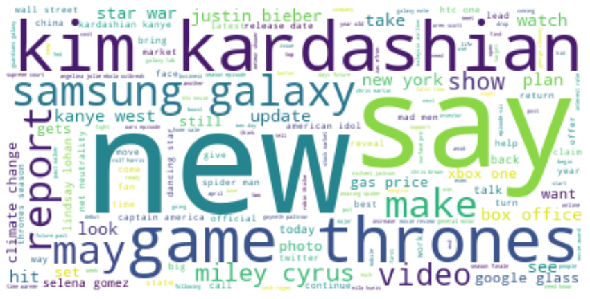

```python
#TITLE = " ".join(i for i in df.NEWSARTICLE)
TITLE = " ".join(i for i in cleaned)
stopwords = set(STOPWORDS)
wordcloud = WordCloud(stopwords=stopwords, background_color="white", max_words=5000, contour_width=3, contour_color='steelblue').generate(TITLE)
plt.figure(figsize=(15,10))
plt.imshow(wordcloud, interpolation='bilinear')
plt.axis("off")
plt.show()
```

```python
def freq_words(x, terms = 10):
  all_words = ' '.join([text for text in x])
  all_words = all_words.split()

  fdist = FreqDist(all_words)
  words_df = pd.DataFrame({'word':list(fdist.keys()), 'count':list(fdist.values())})

  # selecting top 20 most frequent words
  d = words_df.nlargest(columns='count', n = terms)
  plt.figure(figsize=(20,10))
  ax = sns.barplot(data=d, x= 'count', y = 'word', palette = 'GnBu_d')
  ax.set(xlabel = 'COUNT',ylabel = 'WORD')
  plt.rcParams.update({'font.size': 15})
  plt.show()
```

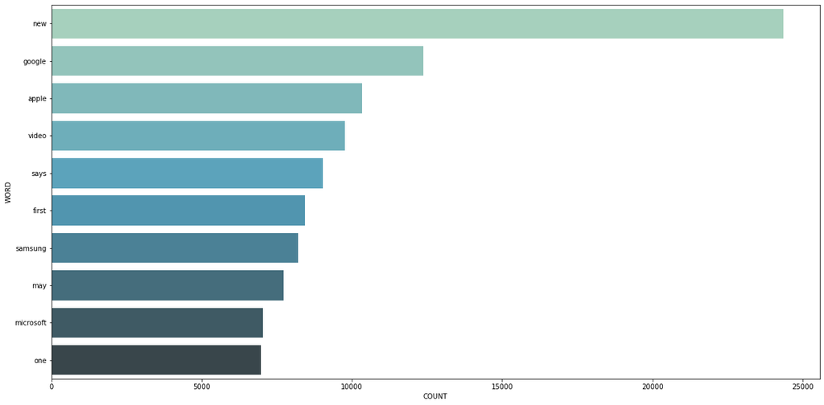

```python
freq_words(cleaned)
```

# **VII. PROCESSING FOR LDA**

## **A. LEMMATIZATION**

```python
nlp = spacy.load('en_core_web_md', disable=['parser', 'ner'])

def lemmatization(texts,allowed_postags=['NOUN', 'ADJ']):
       output = []
       for sent in texts:
             doc = nlp(sent)
             output.append([token.lemma_ for token in doc if token.pos_ in allowed_postags ])
       return output
```

```python
text_list=cleaned.tolist()
print(text_list[1])
tokenized_newspages = lemmatization(text_list)
print(tokenized_newspages[1])
```

```
fed charles plosser sees high bar change pace tapering
['high', 'bar', 'change', 'pace']
```

## **B. MODELLING**

```python
dictionary = corpora.Dictionary(tokenized_newspages)
doc_term_matrix = [dictionary.doc2bow(rev) for rev in tokenized_newspages]
```

```python
# Creating the object for LDA model using gensim library
LDA = gensim.models.ldamodel.LdaModel

# Build LDA model
lda_model = LDA(corpus=doc_term_matrix, id2word=dictionary, num_topics=6, random_state=100,
                chunksize=1000, passes=50,iterations=100)
```

## **C. RESULTING TOPICS**

```python
lda_model.print_topics()
```

```
[(0,
  '0.034*"challenge" + 0.034*"ice" + 0.029*"year" + 0.026*"price" + 0.022*"high" + 0.021*"business" + 0.018*"story" + 0.018*"bucket" + 0.015*"month" + 0.014*"star"'),
 (1,
  '0.043*"stock" + 0.036*"market" + 0.020*"game" + 0.020*"profit" + 0.019*"dollar" + 0.018*"time" + 0.018*"earning" + 0.017*"man" + 0.017*"health" + 0.016*"datum"'),
 (2,
  '0.054*"news" + 0.024*"job" + 0.022*"finale" + 0.021*"top" + 0.020*"rate" + 0.020*"burger" + 0.019*"true" + 0.018*"king" + 0.018*"deal" + 0.017*"music"'),
 (3,
  '0.084*"new" + 0.024*"bad" + 0.022*"good" + 0.018*"trailer" + 0.018*"blood" + 0.017*"ipad" + 0.016*"family" + 0.015*"network" + 0.012*"plan" + 0.012*"company"'),
 (4,
  '0.036*"video" + 0.031*"sale" + 0.030*"big" + 0.026*"article" + 0.022*"award" + 0.021*"movie" + 0.018*"record" + 0.015*"water" + 0.014*"car" + 0.013*"review"'),
 (5,
  '0.022*"report" + 0.020*"case" + 0.020*"full" + 0.015*"bachelor" + 0.014*"first" + 0.014*"house" + 0.013*"galaxy" + 0.012*"late" + 0.012*"outbreak" + 0.011*"gain"')]
```

## **D. LDA DASHBOARD**

```python
# Visualize the topics
#https://github.com/bmabey/pyLDAvis
#https://speakerdeck.com/bmabey/visualizing-topic-models
pyLDAvis.enable_notebook()
vis = pyLDAvis.gensim_models.prepare(lda_model, doc_term_matrix, dictionary)
vis
```

[interactive chart not shown]

## **E. COHERENCE SCORE**

```python
print('\nPerplexity: ', lda_model.log_perplexity(doc_term_matrix,total_docs=10000))  # a measure of how good the model is. lower the better.

# Compute Coherence Score
from gensim.models.coherencemodel import CoherenceModel
coherence_model_lda = CoherenceModel(model=lda_model, texts=tokenized_newspages, dictionary=dictionary , coherence='c_v')
coherence_lda = coherence_model_lda.get_coherence()
print('\nCoherence Score: ', coherence_lda)
```

```
Perplexity:  -11.831561347426375

Coherence Score:  0.32993635516787445
```

### Coherence score for multiple topics

```python
def compute_coherence_values(dictionary, corpus, texts, limit, start=2, step=3):
    """
    Compute c_v coherence for various number of topics

    Parameters:
    ----------
    dictionary : Gensim dictionary
    corpus : Gensim corpus
    texts : List of input texts
    limit : Max num of topics

    Returns:
    -------
    model_list : List of LDA topic models
    coherence_values : Coherence values corresponding to the LDA model with respective number of topics
    """
    coherence_values = []
    model_list = []
    for num_topics in range(start, limit, step):
        model = gensim.models.ldamodel.LdaModel(corpus=corpus, num_topics=num_topics, id2word=dictionary)
        model_list.append(model)
        coherencemodel = CoherenceModel(model=model, texts=texts, dictionary=dictionary, coherence='c_v')
        coherence_values.append(coherencemodel.get_coherence())

    return model_list, coherence_values
```

```python
model_list, coherence_values = compute_coherence_values(dictionary=dictionary, corpus=doc_term_matrix, texts=tokenized_newspages, start=2, limit=10, step=1)
```

[figure not shown]

```python
# Show graph
limit=50; start=2; step=1;
x = range(start, limit, step)
plt.plot(x, coherence_values)
plt.xlabel("Number of Topics")
plt.ylabel("Coherence score")
plt.legend(("coherence_values"), loc='best')
plt.show()
```

```python
for m, cv in zip(x, coherence_values):
    print("Num Topics =", m, " has Coherence Value of", round(cv, 4))
```

[output not shown]

# **VIII. INSIGHTS**

1. Topics formed: **Cluster 1** Finance and Marketing  
   **Cluster 2** Global Trends  
   **Cluster 3** Crime, Disease & Natural Disaster  
   **Cluster 4** Music, TV and Entertainment  
   **Cluster 5** Movies, TV, and Entertainment  
   **Cluster 6** Recent Developments
2. Cluster 4 and 6 overlaps which means their topic seem to have similarities. We can consider updating our stopwords to remove those words causing this overlap OR identify how they can be differentiated. Other clusters are easily distinguishable and identifiable. Upon putting New and News as stopwords and looking at five topics, we have:

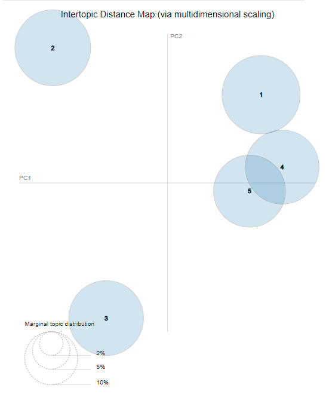

3. Old categories: business, science and technology, entertainment, health. New categories seem to be more descriptive. Also entertainment seem to have a large scope worth to break down into more than one category.
4. LDA model does not account the ‘sense’ or the correlation of each w for each d. In our case, the model seem fit since scraping internet URLs would not necessarily form sensible phrases.

# **VI. REFERENCES**

Data source: https://archive.ics.uci.edu/ml/datasets/News+Aggregator

Dua, D. and Graff, C. (2019). UCI Machine Learning Repository [http://archive.ics.uci.edu/ml]. Irvine, CA: University of California, School of Information and Computer Science.

Bird, S., Klein, E. and Loper, E. (2009). Natural Language Processing with Python. O’Reilly Media, Inc., 1005 Gravenstein Highway North, Sebastopol, CA 95472.

https://www.machinelearningplus.com/nlp/topic-modeling-gensim-python/#14computemodelperplexityandcoherencescore

```python
# for saving to HTML (this was previously done in google colab)
#%%shell
#jupyter nbconvert --to html ///content/GROUP_2_Project_NLP_on_News_Sites.ipynb
```